# Practical Machine Learning Project

## Packages

```r
library(caret)
```

```r
library(rpart)
library(rpart.plot)
library(RColorBrewer)
library(rattle)
library(randomForest)
library(knitr)
library(e1071)
library(repmis)
```

## Background

Using devices such as Jawbone Up, Nike FuelBand, and Fitbit it is now possible to collect a large amount of data about personal activity relatively inexpensively. These type of devices are part of the quantified self movement – a group of enthusiasts who take measurements about themselves regularly to improve their health, to find patterns in their behavior, or because they are tech geeks. One thing that people regularly do is quantify how much of a particular activity they do, but they rarely quantify how well they do it. In this project, your goal will be to use data from accelerometers on the belt, forearm, arm, and dumbell of 6 participants. They were asked to perform barbell lifts correctly and incorrectly in 5 different ways. More information is available from the website here: http://web.archive.org/web/20161224072740/http:/groupware.les.inf.puc-rio.br/har (see the section on the Weight Lifting Exercise Dataset).

## Data

The training data for this project are available here:

https://d396qusza40orc.cloudfront.net/predmachlearn/pml-training.csv

The test data are available here:

https://d396qusza40orc.cloudfront.net/predmachlearn/pml-testing.csv

The data for this project come from this source: http://web.archive.org/web/20161224072740/http:/groupware.les.inf.puc-rio.br/har.

## Load Data

```r
set.seed(12345)

trainUrl <- "http://d396qusza40orc.cloudfront.net/predmachlearn/pml-training.csv"
testUrl <- "http://d396qusza40orc.cloudfront.net/predmachlearn/pml-testing.csv"

trainData <- read.csv(url(trainUrl), na.strings = c("NA", ""))
testData <- read.csv(url(testUrl), na.strings = c("NA", ""))
```

## Clean the Data

Delete the column predictors of the training set that have any missing values.

```r
train_Data <- trainData[, colSums(is.na(trainData)) == 0]
test_Data <- testData[, colSums(is.na(testData)) == 0]
```

Removal of first 7 predictors because they have little predicting power for the class outcome.

```r
training <- train_Data[, -c(1:7)]
testing <- test_Data[, -c(1:7)]
```

### Split the Data

To get out-of-sample errors, the cleaned training set training is split into a training set for prediction and a validation set for calculating out-of-sample errors.

```r
set.seed(726)
inTrain <- createDataPartition(training$classe, p = 0.7, list = FALSE)
train <- training[inTrain, ]
valid <- training[-inTrain, ]
```

## Prediction Algorithms

### Classification Trees

```r
control <- trainControl(method = "cv", number = 5)
rpart_fit <- train(classe ~ ., data = train, method = "rpart",
                   trControl = control)
print(rpart_fit, digits = 4)
```

```
## CART
##
## 13737 samples
##    52 predictor
##     5 classes: 'A', 'B', 'C', 'D', 'E'
##
## No pre-processing
## Resampling: Cross-Validated (5 fold)
## Summary of sample sizes: 10990, 10990, 10990, 10990, 10988
## Resampling results across tuning parameters:
##
##   cp       Accuracy  Kappa
##   0.03428  0.4775    0.31237
##   0.05940  0.4139    0.20529
##   0.11413  0.3309    0.07096
##
## Accuracy was used to select the optimal model using the largest value.
## The final value used for the model was cp = 0.03428.
```

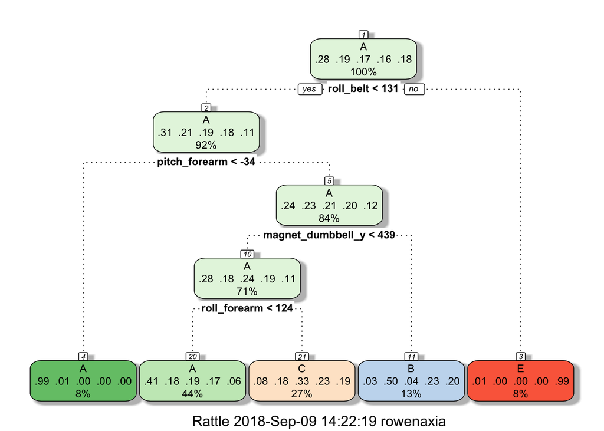

```r
fancyRpartPlot(rpart_fit$finalModel)
```

```r
# predicting the outcomes using the validation set
rpart_predict <- predict(rpart_fit, valid)
# show the result of the prediction
(rpart_conf <- confusionMatrix(valid$classe, rpart_predict))
```

```
## Confusion Matrix and Statistics
##
##           Reference
## Prediction    A    B    C    D    E
##          A 1524   26  119    0    5
##          B  480  391  268    0    0
##          C  460   34  532    0    0
##          D  437  157  370    0    0
##          E  166  136  280    0  500
##
## Overall Statistics
##
##                Accuracy : 0.5008
##                  95% CI : (0.4879, 0.5136)
##     No Information Rate : 0.5212
##     P-Value [Acc > NIR] : 0.9992
##
##                   Kappa : 0.3474
##  Mcnemar's Test P-Value : NA
##
## Statistics by Class:
##
##                      Class: A Class: B Class: C Class: D Class: E
## Sensitivity            0.4969  0.52554   0.3391       NA  0.99010
## Specificity            0.9468  0.85450   0.8855   0.8362  0.89182
## Pos Pred Value         0.9104  0.34328   0.5185       NA  0.46211
## Neg Pred Value         0.6336  0.92562   0.7866       NA  0.99896
## Prevalence             0.5212  0.12642   0.2666   0.0000  0.08581
## Detection Rate         0.2590  0.06644   0.0904   0.0000  0.08496
## Detection Prevalence   0.2845  0.19354   0.1743   0.1638  0.18386
## Balanced Accuracy      0.7218  0.69002   0.6123       NA  0.94096
```

```r
(rpart_accuracy <- rpart_conf$overall[1])
```

```
##  Accuracy
## 0.5007647
```

Based on the confusion matrix, the accuracy is .5008, meaning the out-of-sample error rate is about .5.

## Prediction with Random Forests

```r
rf_fit <- train(classe ~ ., data = train, method = "rf",
                   trControl = control)
print(rf_fit, digits = 4)
```

```
## Random Forest
##
## 13737 samples
##    52 predictor
##     5 classes: 'A', 'B', 'C', 'D', 'E'
##
## No pre-processing
## Resampling: Cross-Validated (5 fold)
## Summary of sample sizes: 10991, 10988, 10989, 10990, 10990
## Resampling results across tuning parameters:
##
##   mtry  Accuracy  Kappa
##    2    0.9899    0.9872
##   27    0.9906    0.9881
##   52    0.9860    0.9822
##
## Accuracy was used to select the optimal model using the largest value.
## The final value used for the model was mtry = 27.
```

```r
# predict the outcomes using the validation set
rf_predict <- predict(rf_fit, valid)
# Show the prediction result
(rf_conf <- confusionMatrix(valid$classe, rf_predict))
```

```
## Confusion Matrix and Statistics
##
##           Reference
## Prediction    A    B    C    D    E
##          A 1673    1    0    0    0
##          B    9 1123    7    0    0
##          C    0    9 1011    6    0
##          D    0    1   10  951    2
##          E    0    1    3    1 1077
##
## Overall Statistics
##
##                Accuracy : 0.9915
##                  95% CI : (0.9888, 0.9937)
##     No Information Rate : 0.2858
##     P-Value [Acc > NIR] : < 2.2e-16
##
##                   Kappa : 0.9893
##  Mcnemar's Test P-Value : NA
##
## Statistics by Class:
##
##                      Class: A Class: B Class: C Class: D Class: E
## Sensitivity            0.9946   0.9894   0.9806   0.9927   0.9981
## Specificity            0.9998   0.9966   0.9969   0.9974   0.9990
## Pos Pred Value         0.9994   0.9860   0.9854   0.9865   0.9954
## Neg Pred Value         0.9979   0.9975   0.9959   0.9986   0.9996
## Prevalence             0.2858   0.1929   0.1752   0.1628   0.1833
## Detection Rate         0.2843   0.1908   0.1718   0.1616   0.1830
## Detection Prevalence   0.2845   0.1935   0.1743   0.1638   0.1839
## Balanced Accuracy      0.9972   0.9930   0.9888   0.9950   0.9986
```

For this set of data, the random forest method is a much better method than the classification tree method. The overall accuracy is .9915, making the out-of-sample error rate about .0085.

## Prediction on Testing Set

```r
(predict(rf_fit, testing))
```

```
##  [1] B A B A A E D B A A B C B A E E A B B B
## Levels: A B C D E
```